# Ecosystem Functioning and Functional Diversity

Alexander Hurley

Wednesday, June 24, 2015

*Note: ‘experiments’ should be termed ‘scenarios’; will be changed. Formatting of axis labels, etc. will be done for the final report / dissertation*

# Foreword

This document briefly outlines the rationale behind the experimental design and traces the first tentative steps in the data analysis. The entire analysis (i.e. all scripts, functions, required packages and code for this document) are available in my [Dissertation](https://github.com/the-Hull/Diss) github repository.

## Hypothesis

*Community composition (which groups are present) is a stronger determinant of ecosystem functioning than functional diversity (how many groups are present).*, where community composition refers to the ‘horizontal diversity’ of carnivorous functional groups. In this study, ecosystem functioning is measured as biomass density [$kg/{km^2}$] of one or ratios of two trophic group(s).

## Overview

Ecosystem functioning (**biomass density** [$kg/km^{2}$]) was simulated for 7 experiments of different functional diversity and community composition. Here-fore, functional diversity was decreased step-wise by removing carnivorous functional groups (in different combinations for the removal of 2 groups) - essentially a nested design with $n = 7$ factor combinations (including one control). This approach does not alter the trophic structure of the system, i.e. carnivores remain. For each experiment, 100 simulations were done to capture variability (as the model is not deterministic) over 100 years at a monthly resolution. Results of a final experiment (ExpNo == 8) were recorded in order to identify whether the reduction of functional diversity (or a given combination of groups) would result in a dynamic comparable to a trophically less complex system. This table gives a brief overview of the experiment design.

| ExpNo | Label_Verbose | RM_No | Label_Abb | Sims | Duration |
| --- | --- | --- | --- | --- | --- |
| 1 | Removed: None | 0 | C(end) + C(ect)s + C(ect)i | 100 | 100 |
| 2 | Removed: end. Carnivores | 1 | C(ect)i + C(ect)s | 100 | 100 |
| 3 | Removed: ecto. Carnivores (semelp.) | 1 | C(end) + C(ect)i | 100 | 100 |
| 4 | Removed: ecto. Carnivores (itero.) | 1 | C(end) + C(ect)s | 100 | 100 |
| 5 | Removed: end. Carnivores + ecto. Carnivores (semelp.) | 2 | C(ect)i | 100 | 100 |
| 6 | Removed: end. Carnivores + ecto. Carnivores (itero.) | 2 | C(ect)s | 100 | 100 |
| 7 | Removed: ecto. Carnivores (semelp.) + ecto. Carnivores (iterop.) | 2 | C(end) | 100 | 100 |
| 8 | Removed: all Carnivores | 3 | C(-) | 100 | 100 |

The data for each experiment were collated, i.e. each time step is represented by 100 data points resulting from their respective simulations.

## Results

Ecosystem functioning was simulated for different combinations of functional diversity (3 levels) and community composition (7 levels).

### Trophic Dynamics in aseasonal and seasonal Ecosystems

The following plots show the log. biomass density [$kg/km^{2}$] (and corresponding 95 % CI) for the aseasonal and seasonal ecosystems on the left and right panels, respectively, for experiments 1 (control) through 7.

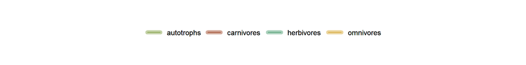

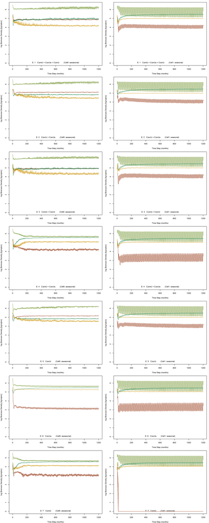

### Trends vs. Steady State

To identify steady states in the experimental systems, time series of each individual trophic group per experiment were decomposed into seasonal / random and trend components. Linear models were fitted to each trend component to test for non-zero slopes, signifying that the systems have not yet reached steady state. An optimization function was implemented to identify the optimal time interval (i.e. cut-off) by minimizing the number of non-zero slopes found throughout all experiments and functional groups. A scanning window between years 50 and 95 was used for the following plot.  
The optimal cut-off was determined at 90 years. Steady state was not reached in numerous cases. However, visual examination of the time series shows that the trophic groups in each system (aseasonal, seasonal) display distinct responses and/or trajectories that are consistent in pattern and magnitude after approx. 50 years. In addition, the observable trends are minimal and are hence regarded as negligible when a cut-off of 90 years is used.

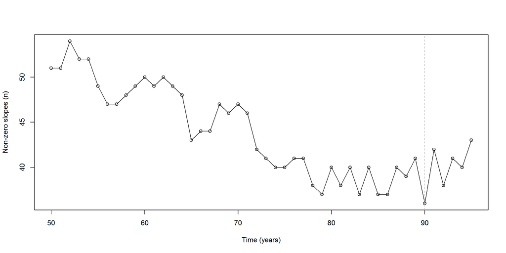

### Functional Diversity and Community Composition Effects

The following box plot shows the log. biomass density [$kg/km^{2}$] for trophic groups by experiment, allowing for direct comparison of the effects of reducing functional diversity from 9 (exp. 1) to 8 (exp. 2–4) to 7 (exp. 5–7) under different community composition. The data shown here is cut off after 90 years (i.e. 1080 time steps) into the simulations, with the aseasonal and seasonal systems in the top and bottom panel, respectively.

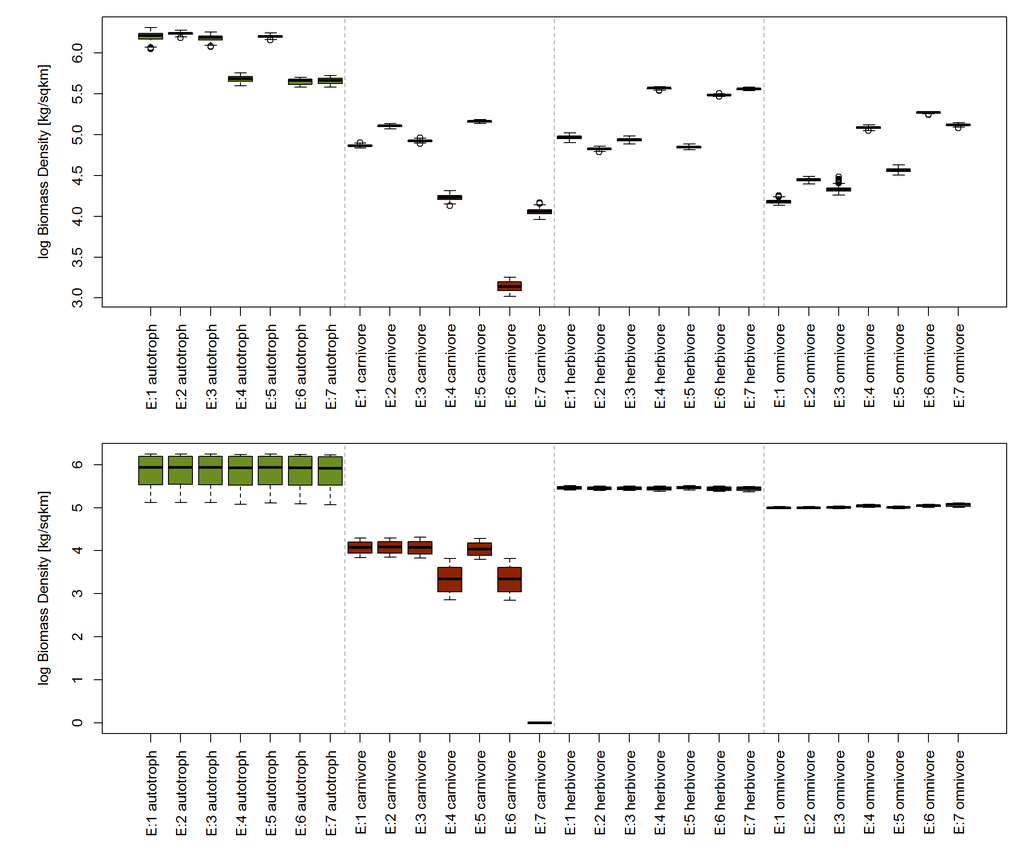

#### Heterotroph - Autotroph Ratios

Median ratios of heterotroph to autotroph biomass density were calculated for each time step from 100 simulations. The box plot below shows these ratios for experiment 1 through 7 after year 90. Darker colors mark higher functional diversity.

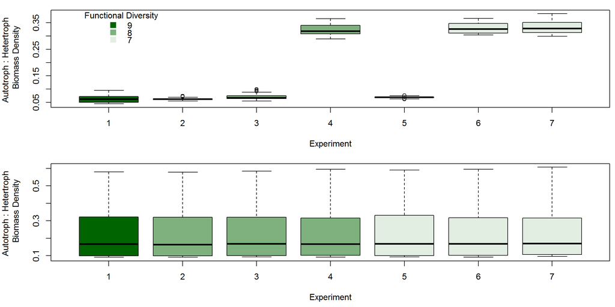

[output not shown]

#### Herbivore - Autotroph Ratios

Analogous, this plot shows ratios of herbivores to autotrophs.

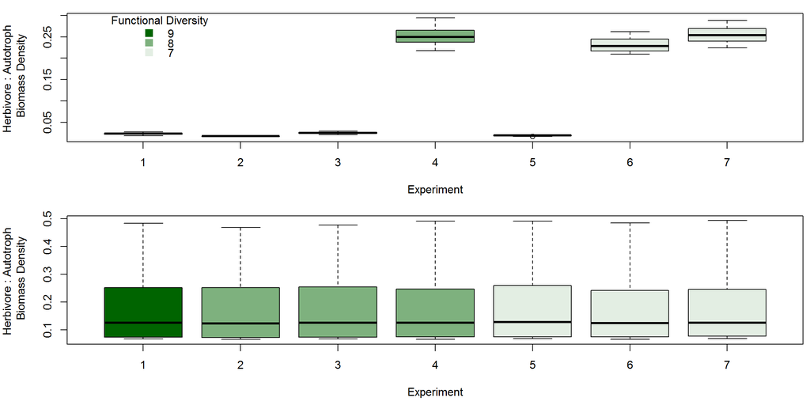

*Short summary*: The exploratory analysis (cf. plots above) already shows that experiments 4, 6 and 7 lead to distinct dynamics in the aseasonal ecosystem. I.e. both absolute values for all heterotrophic groups differ from the control, as well as from the other experiments. However, no clear differences between the control (exp. 1) and experiments 2, 3 and 5 are apparent.  
The pattern that can be drawn off, is that the effect of removing iteroparous ectothermic carnivores from the community is larger than the decrease of carnivore functional diversity **per se**. Both omnivores and herbivores respond to the removal of iter. ect. carnivores by increasing their biomass density, while the remaining carnivorous groups decrease.

#### Statistical Assessment

**Herbivore vs. Experiments** The following passage shows significant differences (for $\alpha = 0.05$) for log herbivore biomass density between experiments (1 to 7) by assigning different letter groupings (column M). (From visual examination, residuals seem to be distributed fairly evenly for all of the following cases)

```
[1] "Results for one-way Anova: Herbivore (log Median BiomassDens ~ ExpNo"
```

```
[1] "For Cell0"
```

```
              Df Sum Sq Mean Sq F value Pr(>F)
ExpNo          6 220.10   36.68  163329 <2e-16 ***
Residuals   2107   0.47    0.00
---
Signif. codes:  0 '***' 0.001 '**' 0.01 '*' 0.05 '.' 0.1 ' ' 1
```

```
  trt    means M
1   4 5.566997 a
2   7 5.558816 b
3   6 5.484937 c
4   1 4.963387 d
5   3 4.937428 e
6   5 4.845977 f
7   2 4.824912 g
```

```
[1] "For Cell1"
```

```
              Df Sum Sq  Mean Sq F value Pr(>F)
ExpNo          6  0.161 0.026834   22.86 <2e-16 ***
Residuals   2107  2.473 0.001174
---
Signif. codes:  0 '***' 0.001 '**' 0.01 '*' 0.05 '.' 0.1 ' ' 1
```

```
  trt    means  M
1   5 5.463673  a
2   1 5.458836 ab
3   3 5.452791  b
4   2 5.451226  b
5   4 5.442815  c
6   6 5.440674  c
7   7 5.439030  c
```

**Herbivore : Autotroph Ratios vs Experiments**

Analogous to above; results of a one-way ANOVA for herbivore-autotroph ratios. Groupings affirm the visual impression of the plots above.

```
[1] "For Cell0"
```

```
             Df Sum Sq Mean Sq F value Pr(>F)
ExpNo         1  146.4  146.41   854.7 <2e-16 ***
Residuals   852  146.0    0.17
---
Signif. codes:  0 '***' 0.001 '**' 0.01 '*' 0.05 '.' 0.1 ' ' 1
```

```
  trt       means  M
1   7 -0.09945308  a
2   4 -0.10678405  a
3   6 -0.15552192  a
4   3 -1.21726120  b
5   1 -1.25451535 bc
6   5 -1.33458073 bc
7   2 -1.37996313  c
```

```
[1] "For Cell1"
```

```
             Df Sum Sq Mean Sq F value Pr(>F)
ExpNo         1   0.03 0.02607   0.186  0.666
Residuals   852 119.43 0.14018
```

```
  trt      means M
1   7 -0.3665079 a
2   5 -0.3686881 a
3   4 -0.3772037 a
4   6 -0.3781719 a
5   3 -0.3805670 a
6   1 -0.3808464 a
7   2 -0.3893990 a
```

### Model Building

The models above use the log. median biomass density of a trophic group, or ratios of combinations of trophic groups. After cutting the data at 90 years (1080 time steps), the remaining data points are treated as independent observations of one set (i.e. a 10 year window). This is based on the assumption of the respective systems having stable and distinct trajectories.

As the experiment design is nested, building a model to identify effect sizes for functional diversity and community composition is not straight-forward.  
Functional diversity (including the control) has 3 levels. Within these 3 levels, there are thee different types of combinations for carnivorous groups (CG):  
**“polyculture”** = all CG – ABC  
**“biculture”** = 2 CG – AB / AC / BC  
**“monoculture”** = 1 CG – A / B / C  
With 7 individual levels.

As most differences seem to result from removing either endothermic or iteroparous ectothermic carnivores, I am wondering if it may be appropriate / better to collapse the levels further. Levels could carry information on whether the system has endothermic, iteroparous ecto., both or no carnivore groups present:

**“polyculture”** = all CG – C (control)  
**“biculture”** = 2 CG – Both / i-E / End  
**“monoculture”** = 1 CG – i-E / End / Neither

## Questions

I am still working on solving the following:

*Is an ANOVA the right approach or is GLM more suitable?* This stems from the fact that the data is actually a time series, and therefore depends on seasonality and periodic dynamics. The assumption of cutting off the data after 90 years and assuming a steady state must be solid for using an ANOVA.  
Building a model to predict e.g. herbivore - autotroph ratios based on functional diversity and community composition may be more attractive and reasonable. E.g.: $\log{ (\frac{H}{A})} = c + \beta_{1} \cdot (Functional Diversity) \cdot \beta_{2} \cdot (Composition) \cdot \beta_{3} \cdot (Month) + \epsilon$

Rather than testing against a Null-Hypothesis in an ANOVA set-up, I could compare models, calculate effect sizes ($\beta$) and test against a reasonable Null-model. However, I’m not entirely sure if the GLM(M) frame work is suitable here.

*End of Document*